# Modeling and prediction for movies

## Part 4: Modeling

I am expecting a linear relationship between the variables as explained in the previous section. Therefore, I am going to use a linear regression model. Initially, I will fit all useful variables into the model and I am going to eliminate variables one at a time using the Adjusted R-squared value. This helps me to corner down on very important variables without losing out on other variables.

The variables I will neglect are actor names, director names, title, urls, dvd release variable, studio as they will not give me any information regarding audience score. They are just information to identify the movie and not the audience score. All the remaining variables are considered for my model below.

Let the initial model be with 16 variables as below;

```r
mod1 <- lm(audience_score~title_type+genre+runtime+mpaa_rating+thtr_rel_year+thtr_rel_month+thtr_rel_day+imdb_rating+imdb_num_votes+critics_rating+critics_score+best_pic_nom+best_pic_win+best_actor_win+best_actress_win+best_dir_win, data = movies)
summary(mod1)
```

```
##
## Call:
## lm(formula = audience_score ~ title_type + genre + runtime +
##     mpaa_rating + thtr_rel_year + thtr_rel_month + thtr_rel_day +
##     imdb_rating + imdb_num_votes + critics_rating + critics_score +
##     best_pic_nom + best_pic_win + best_actor_win + best_actress_win +
##     best_dir_win, data = movies)
##
## Residuals:
##     Min      1Q  Median      3Q     Max
## -26.549  -5.892   0.162   5.524  49.194
##
## Coefficients:
##                                  Estimate Std. Error t value Pr(>|t|)
## (Intercept)                     1.877e+02  8.444e+01   2.223  0.02654 *
## title_typeFeature Film          1.155e+00  3.652e+00   0.316  0.75180
## title_typeTV Movie              1.756e+00  5.728e+00   0.306  0.75936
## genreAnimation                  9.549e+00  3.846e+00   2.483  0.01329 *
## genreArt House & International -2.917e-01  2.998e+00  -0.097  0.92253
## genreComedy                     2.461e+00  1.639e+00   1.502  0.13360
## genreDocumentary                2.718e+00  3.912e+00   0.695  0.48747
## genreDrama                      7.994e-01  1.447e+00   0.553  0.58079
## genreHorror                    -5.515e+00  2.444e+00  -2.257  0.02437 *
## genreMusical & Performing Arts  6.041e+00  3.356e+00   1.800  0.07236 .
## genreMystery & Suspense        -4.989e+00  1.846e+00  -2.703  0.00707 **
## genreOther                      5.174e-01  2.797e+00   0.185  0.85330
## genreScience Fiction & Fantasy -1.365e+00  3.495e+00  -0.391  0.69624
## runtime                        -4.057e-02  2.482e-02  -1.635  0.10263
## mpaa_ratingNC-17               -5.122e+00  7.409e+00  -0.691  0.48962
## mpaa_ratingPG                   1.523e+00  2.697e+00   0.565  0.57240
## mpaa_ratingPG-13                5.100e-01  2.834e+00   0.180  0.85726
## mpaa_ratingR                    7.416e-01  2.706e+00   0.274  0.78414
## mpaa_ratingUnrated              2.864e+00  3.163e+00   0.905  0.36561
## thtr_rel_year                  -1.079e-01  4.188e-02  -2.576  0.01022 *
## thtr_rel_month                 -1.898e-01  1.135e-01  -1.672  0.09512 .
## thtr_rel_day                    2.385e-02  4.483e-02   0.532  0.59489
## imdb_rating                     1.486e+01  6.207e-01  23.941  < 2e-16 ***
## imdb_num_votes                  5.731e-06  4.586e-06   1.250  0.21185
## critics_ratingFresh            -2.592e+00  1.258e+00  -2.060  0.03981 *
## critics_ratingRotten           -5.159e+00  1.987e+00  -2.596  0.00965 **
## critics_score                  -5.734e-03  3.593e-02  -0.160  0.87326
## best_pic_nomyes                 4.924e+00  2.586e+00   1.904  0.05741 .
## best_pic_winyes                -4.196e+00  4.537e+00  -0.925  0.35533
## best_actor_winyes              -1.125e+00  1.163e+00  -0.967  0.33372
## best_actress_winyes            -2.108e+00  1.288e+00  -1.637  0.10212
## best_dir_winyes                -1.079e+00  1.689e+00  -0.639  0.52316
## ---
## Signif. codes:  0 '***' 0.001 '**' 0.01 '*' 0.05 '.' 0.1 ' ' 1
##
## Residual standard error: 9.731 on 618 degrees of freedom
##   (1 observation deleted due to missingness)
## Multiple R-squared:  0.7798, Adjusted R-squared:  0.7687
## F-statistic: 70.59 on 31 and 618 DF,  p-value: < 2.2e-16
```

```r
summary(mod1)$adj.r.squared
```

```
## [1] 0.7687395
```

Adjusted R-squared at this step = 0.7687. We can see from the p-values which variables are significant and can remove other variables. The p-values are greater than 0.05, we can say that they do not significantly contribute to the audience score. Therefore, we can eliminate these variables where p-value is higher than 0.05 in our next step and check adjusted R-squared values again.

The variables that have p-value higher than 0.05 and can be removed are:

title_type; mpaa_rating; thtr_rel_month; thtr_rel_day; imdb_num_votes; critics_score; best_pic_nom; best_pic_win; best_actor_win; best_actress_win; best_dir_win;

```r
mod2 <- lm(audience_score~title_type+genre+runtime+mpaa_rating+thtr_rel_year+thtr_rel_month+thtr_rel_day+imdb_rating+imdb_num_votes+critics_rating+critics_score, data = movies)
summary(mod2)$adj.r.squared
```

```
## [1] 0.7678339
```

We can see that the Adjusted R-squared at this step is 0.7678. This means there is some variable that is present in the eliminated variables that is contributing to the audience score. After trial and error, it is found that the best actress variable has slight impact on the audience score. Therefore, we are adding the variable back to the model.

```r
mod3 <- lm(audience_score~title_type+genre+runtime+mpaa_rating+thtr_rel_year+thtr_rel_month+thtr_rel_day+imdb_rating+imdb_num_votes+critics_rating+critics_score+best_actress_win, data = movies)
summary(mod3)$adj.r.squared
```

```
## [1] 0.7683712
```

```r
mod4 <- lm(audience_score~title_type+genre+runtime+mpaa_rating+thtr_rel_year+imdb_rating+imdb_num_votes+critics_rating+critics_score+best_actress_win, data = movies)
summary(mod4)$adj.r.squared
```

```
## [1] 0.7682566
```

Adjusted R-squared = 0.7683 after removing 2 variables (theatre release day & month).

```r
mod5 <- lm(audience_score~genre+runtime+thtr_rel_year+imdb_rating+critics_rating+best_actress_win, data = movies)
summary(mod5)$adj.r.squared
```

```
## [1] 0.7699599
```

Adjusted R-squared = 0.77 after removing 4 variables (title type, mpaa rating, imdb number of votes, critics score)

This is the best adjusted R-square value I have arrived by removing variables according to their p-value. If I remove even one variable after this, there is a decrease in the R-squared value. Though p-value of best actress is more than 0.05, it is affecting the audience score, adjusted R-square value and therefore, the variable is still included in the final model.

We are finally left with 6 variables that best predict the value of audience score.

## Diagnostics for Regression Line

We have to meet the 3 criteria mentioned for the best fit as mentioned in the course:

1. Linear relation between variables
2. Constant Variability of residuals plot
3. Distribution of residuals around 0.

We saw earlier that the audience score and imdb ratings were linearly related. The model also contains imdb rating and therefore, we can say that there is linear relation between variables.

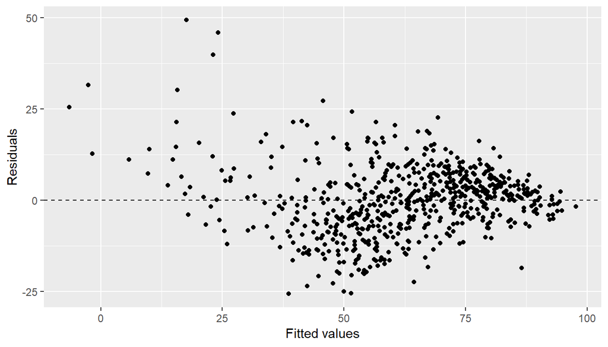

```r
ggplot(data = mod5, aes(x = .fitted, y = .resid)) +
  geom_point() +
  geom_hline(yintercept = 0, linetype = "dashed") +
  xlab("Fitted values") +
  ylab("Residuals")
```

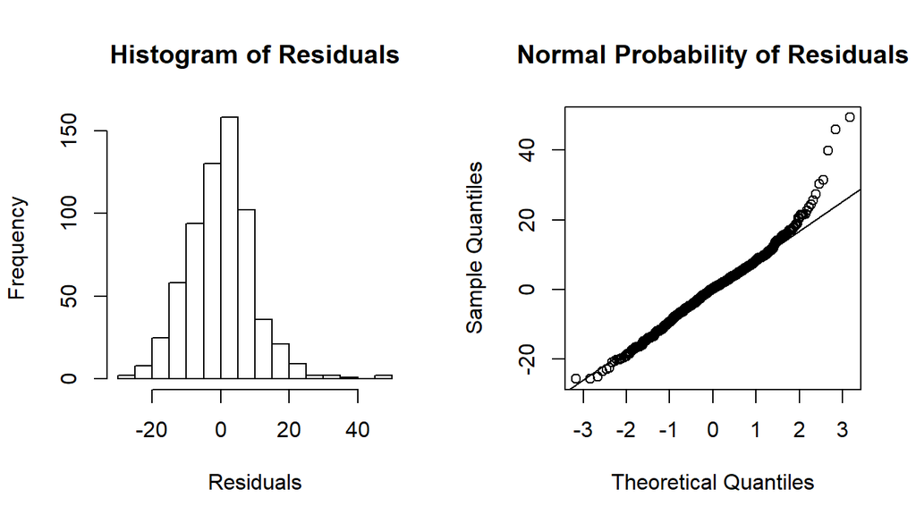

```r
par(mfrow=c(1,2))
hist(mod5$residuals, main='Histogram of Residuals',xlab = "Residuals")
qqnorm(mod5$residuals,main='Normal Probability of Residuals')
qqline(mod5$residuals)
```

We can see that the distribution of the residuals is also similar to normal distribution centered around 0. Therefore, condition of normal distribution of the residuals is also met.